# Vehicle_Price_Prediction

Alejandro Alvarez

2026-05-31

```r
knitr::opts_chunk$set(echo = TRUE)

library(tidyverse)
```

# Vehicle Price Prediction

## Data Overview

```r
cars <- read_csv("data/car_prices.csv")
names(cars)
```

```
##  [1] "year"         "make"         "model"        "trim"         "body"
##  [6] "transmission" "vin"          "state"        "condition"    "odometer"
## [11] "color"        "interior"     "seller"       "mmr"          "sellingprice"
## [16] "saledate"
```

```r
summary(cars)
```

```
##       year          make              model               trim
##  Min.   :1982   Length:558837      Length:558837      Length:558837
##  1st Qu.:2007   Class :character   Class :character   Class :character
##  Median :2012   Mode  :character   Mode  :character   Mode  :character
##  Mean   :2010
##  3rd Qu.:2013
##  Max.   :2015
##
##      body           transmission           vin               state
##  Length:558837      Length:558837      Length:558837      Length:558837
##  Class :character   Class :character   Class :character   Class :character
##  Mode  :character   Mode  :character   Mode  :character   Mode  :character
##
##
##
##
##    condition        odometer         color             interior
##  Min.   : 1.00   Min.   :     1   Length:558837      Length:558837
##  1st Qu.:23.00   1st Qu.: 28371   Class :character   Class :character
##  Median :35.00   Median : 52254   Mode  :character   Mode  :character
##  Mean   :30.67   Mean   : 68320
##  3rd Qu.:42.00   3rd Qu.: 99109
##  Max.   :49.00   Max.   :999999
##  NA's   :11820   NA's   :94
##     seller               mmr          sellingprice      saledate
##  Length:558837      Min.   :    25   Min.   :     1   Length:558837
##  Class :character   1st Qu.:  7100   1st Qu.:  6900   Class :character
##  Mode  :character   Median : 12250   Median : 12100   Mode  :character
##                     Mean   : 13769   Mean   : 13611
##                     3rd Qu.: 18300   3rd Qu.: 18200
##                     Max.   :182000   Max.   :230000
##                     NA's   :38       NA's   :12
```

```r
colSums(is.na(cars))
```

```
##         year         make        model         trim         body transmission
##            0        10301        10399        10651        13195        65352
##          vin        state    condition     odometer        color     interior
##            4            0        11820           94          749          749
##       seller          mmr sellingprice     saledate
##            0           38           12           12
```

## Data Clean up

Create a clean data set

```r
cars_clean <- cars |>
  select(sellingprice, year, odometer, condition) |>
  drop_na()

dim(cars_clean)
```

```
## [1] 546976      4
```

```r
colSums(is.na(cars_clean))
```

```
## sellingprice         year     odometer    condition
##            0            0            0            0
```

```r
summary(cars_clean)
```

```
##   sellingprice         year         odometer        condition
##  Min.   :     1   Min.   :1982   Min.   :     1   Min.   : 1.00
##  1st Qu.:  7100   1st Qu.:2008   1st Qu.: 28050   1st Qu.:23.00
##  Median : 12300   Median :2012   Median : 51223   Median :35.00
##  Mean   : 13764   Mean   :2010   Mean   : 67263   Mean   :30.67
##  3rd Qu.: 18300   3rd Qu.:2013   3rd Qu.: 97393   3rd Qu.:42.00
##  Max.   :230000   Max.   :2015   Max.   :999999   Max.   :49.00
```

Summary

Missing values were handled by listwise deletion for the baseline model. After removing observations with missing values in selling price, condition, and odometer, 546,976 observations remained for analysis.

## Build a baseline regression

- sellingprice = what we’re trying to predict
- year = vehicle age
- odometer = mileage
- condition = vehicle condition

sellingprice=β0+β1(year)+β2(odometer)+β3(condition)

## Baseline Regression Model

```r
model1 <- lm(
  sellingprice ~ year + odometer + condition,
  data = cars_clean
)
summary(model1)
```

```
##
## Call:
## lm(formula = sellingprice ~ year + odometer + condition, data = cars_clean)
##
## Residuals:
##    Min     1Q Median     3Q    Max
## -20638  -4859  -1593   2803 210000
##
## Coefficients:
##               Estimate Std. Error t value Pr(>|t|)
## (Intercept) -1.500e+06  8.445e+03  -177.6   <2e-16 ***
## year         7.534e+02  4.195e+00   179.6   <2e-16 ***
## odometer    -5.656e-02  3.079e-04  -183.7   <2e-16 ***
## condition    8.852e+01  8.194e-01   108.0   <2e-16 ***
## ---
## Signif. codes:  0 '***' 0.001 '**' 0.01 '*' 0.05 '.' 0.1 ' ' 1
##
## Residual standard error: 7605 on 546972 degrees of freedom
## Multiple R-squared:  0.3913, Adjusted R-squared:  0.3913
## F-statistic: 1.172e+05 on 3 and 546972 DF,  p-value: < 2.2e-16
```

## Estimated Regression Equation

sellingprice = −1,500,000+753.4(year)−0.0566(odometer)+88.5(condition)

Interpretation Year Coefficient: 753.4.

For each additional model year, the expected selling price increases by about $753, holding mileage and condition constant.

Odometer

Coefficient:

−0.0566

For each additional mile on the odometer, the expected selling price decreases by about 5.7 cents, holding other variables constant.

Example:

10,000 additional miles:

10,000×0.0566=$566

So an extra 10,000 miles lowers value by approximately $566.

Condition

Coefficient:

88.5

Each one-point increase in vehicle condition increases expected selling price by about $89, holding other variables constant.

Model Fit R 2 =0.3913

Interpretation:

Approximately 39.1% of the variation in vehicle selling prices is explained by vehicle year, mileage, and condition.

This is actually reasonable for a very simple baseline model.

A baseline regression model was estimated using vehicle year, odometer reading, and condition as predictors of selling price. All variables were statistically significant at the 1% level (p < 0.001). The model explained approximately 39.1% of the variation in selling prices (R² = 0.3913), indicating that additional vehicle characteristics may be needed to improve predictive performance.

## Exploratory Data Analysis

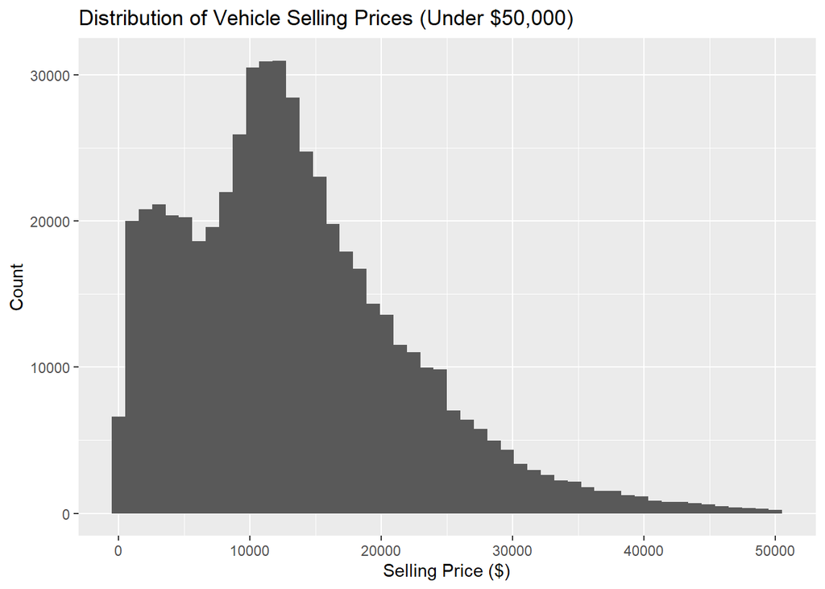

```r
cars_hist <- cars_clean %>%
  filter(sellingprice <= 50000)

ggplot(cars_hist, aes(x = sellingprice)) +
  geom_histogram(bins = 50) +
  labs(
    title = "Distribution of Vehicle Selling Prices (Under $50,000)",
    x = "Selling Price ($)",
    y = "Count"
  )
```

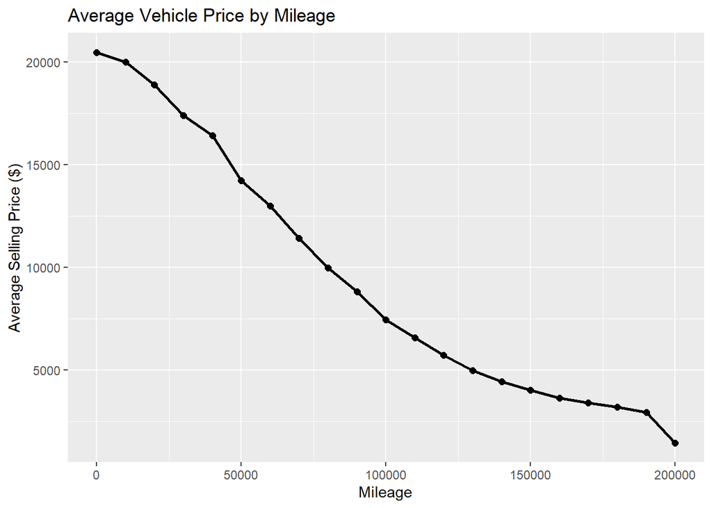

```r
cars_scatter <- cars_clean %>%
  filter(
    sellingprice <= 50000,
    odometer <= 200000
  )
cars_band <- cars_scatter %>%
  mutate(mileage_band = floor(odometer/10000)*10000) %>%
  group_by(mileage_band) %>%
  summarize(avg_price = mean(sellingprice))

ggplot(cars_band,
       aes(x = mileage_band,
           y = avg_price)) +
  geom_line(linewidth = 1) +
  geom_point(size = 2) +
  labs(
    title = "Average Vehicle Price by Mileage",
    x = "Mileage",
    y = "Average Selling Price ($)"
  )
```

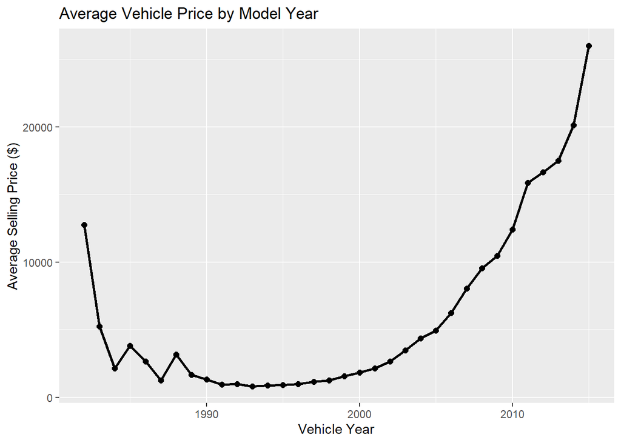

```r
cars_year <- cars_clean %>%
  group_by(year) %>%
  summarize(avg_price = mean(sellingprice))

ggplot(cars_year,
       aes(x = year,
           y = avg_price)) +
  geom_line(linewidth = 1) +
  geom_point(size = 2) +
  labs(
    title = "Average Vehicle Price by Model Year",
    x = "Vehicle Year",
    y = "Average Selling Price ($)"
  )
```

Average vehicle selling prices increase with model year, indicating that newer vehicles command higher market values. The relationship becomes especially pronounced for vehicles produced after 2005. This finding is consistent with the positive coefficient on vehicle year observed in the baseline regression model.

The unusually high average prices for the oldest model years are likely driven by a small number of observations and should be interpreted with caution.